# CIND 123 - Data Analytics: Basic Methods

## Question 2 (15 points)

In a shipment of 20 engines, history shows that the probability of any one engine proving unsatisfactory is 0.1

1. What will be the probability that all 20 engines are satisfactory? (5 points)

```r
#INSERT YOUR ANSWER HERE
dbinom(x=20, size=20, prob=0.9)
```

```
## [1] 0.1215767
```

2. Use the Binomial approximation to calculate the probability that more than 10 engines are defective? (5 points)

```r
#INSERT YOUR ANSWER HERE
1 - pbinom(10, size=20, prob=0.1)
```

```
## [1] 7.088606e-07
```

3. Use the binomial approximation to calculate the probability that at most three engines are defective? (5 points)

```r
#INSERT YOUR ANSWER HERE
pbinom(3, size=20, prob=0.1)
```

```
## [1] 0.8670467
```

## Question 3 (25 points)

On average, John goes to his parents’ place twice a week for visits.

1. What will be the probabilities if John decides not to visit at all and then does 1, 2, 3, 4 and 5 visits to his parents in the subsequent weeks?(5 points)

```r
#INSERT YOUR ANSWER HERE
# Avg visits = 2
dpois(0, lambda=2)
```

```
## [1] 0.1353353
```

```r
dpois(1, lambda=2)
```

```
## [1] 0.2706706
```

```r
dpois(2, lambda=2)
```

```
## [1] 0.2706706
```

```r
dpois(3, lambda=2)
```

```
## [1] 0.180447
```

```r
dpois(4, lambda=2)
```

```
## [1] 0.09022352
```

```r
dpois(5, lambda=2)
```

```
## [1] 0.03608941
```

2. Find the probability that John goes to his parents’ place 3 times or less in a week? (5 points)

```r
#INSERT YOUR ANSWER HERE
ppois(q=3, lambda=2)
```

```
## [1] 0.8571235
```

3. Compare the similarity between Binomial and Poisson distribution. (15 points @ 5 point each)
1. Create 100,000 samples for a Binomial random variable using parameters described in Question 2
2. Create 100,000 samples for a Poisson random variable using parameters described in Question 3
3. then illustrate on how well the Poisson probability distribution approximates the Binomial probability distribution. Please provide your result by visualizing through a comparative histogram. HINT: use multhist() from the ‘plotrix’ package. Please install if plotrix package is not in your R environment.

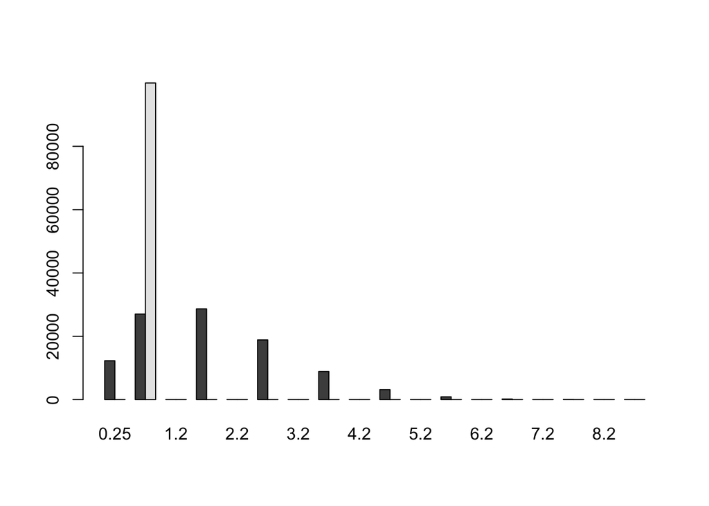

```r
#INSERT YOUR ANSWER HERE
#install.packages("plotrix")
library(plotrix)
# Question 2 : size=20 prob=0.1 & Question 3 : prob=2
x <- c(0:100000)
sample1 <- rbinom(x, size=20, prob=0.1)
sample2 <- ppois(x, 2)
compare_dist <- list(sample1, sample2)
multhist(compare_dist, beside=TRUE, plot.it=TRUE)
```

## Question 4 (20 points)

Given the following conditions of a normal random variable having mean = 16 and variance = 9, please write the R codes to find the probabilities and their values when,

1. lies between 14.4 and 20.3 (inclusive) (5 points)

```r
#INSERT YOUR ANSWER HERE
pnorm(20.3, 16, sd=3) - pnorm(14.4, 16, sd=3)
```

```
## [1] 0.6272173
```

2. is greater than 21.8 (5 points)

```r
#INSERT YOUR ANSWER HERE
1-pnorm(21.8, 16, sd=3)
```

```
## [1] 0.02659757
```

3. is less than or equal to 10.5 (5 points)

```r
#INSERT YOUR ANSWER HERE
pnorm(10.5, 16, sd=3)
```

```
## [1] 0.03337651
```

4. is less than 13 or greater than 19 (5 points)

```r
#INSERT YOUR ANSWER HERE
pnorm(13, 16, sd=3) + 1-pnorm(19, 16, sd=3)
```

```
## [1] 0.3173105
```

END of Assignment #2.